# metabolism

mcdevitt

26 mars 2017

## Metabolism - Analysis

The Metabolic data on Canvas has the average mass, metabolic rate and average lifespan of 95 different species of mammals. Kleiber’s law states that the metabolic rate of an animal species, on average, is proportional to its mass raised to the power of ¾. Judge the adequacy of this theory with these data.

### **Structure of Data Set (with added columns for log transforms)**

```r
str(s26)
```

```
## 'data.frame':    95 obs. of  8 variables:
##  $ CommonName : chr  "Echidna" "Long-beaked echidna" "Platypus" "Opossum" ...
##  $ Species    : chr  "Tachiglossus aculeatus" "Zaglossus bruijni" "Ornithorhynchus anatinus" "Lutreolina crassicaudata" ...
##  $ Mass       : num  2.5 10.3 1.3 0.812 1.33 3.26 0.0141 0.00365 0.0085 0.089 ...
##  $ Metab      : num  302 594 229 196 299 519 9 17.6 5.17 37.4 ...
##  $ Life       : num  14 20 9 5 6 8 2 2.5 2 3 ...
##  $ m34        : num  1.988 5.749 1.217 0.855 1.238 ...
##  $ log_mass_75: num  0.687 1.749 0.197 -0.156 0.214 ...
##  $ log_metab  : num  5.71 6.39 5.43 5.28 5.7 ...
```

#### **Add some basic plots for data exploration**

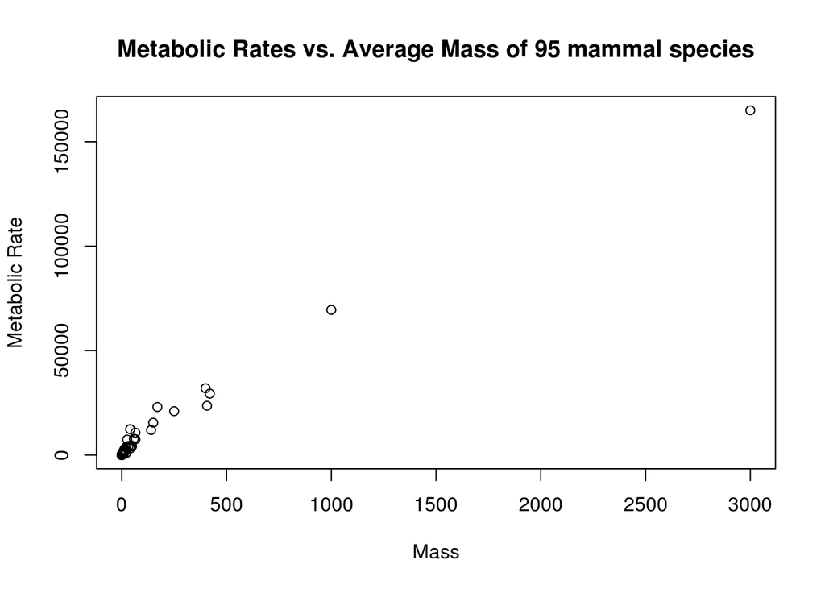

```r
plot(s26$Metab ~ s26$Mass,
     main = "Metabolic Rates vs. Average Mass of 95 mammal species",
     xlab = "Mass",
     ylab = "Metabolic Rate")
```

##### Data set shows very right skewed distribution in both x and y axes as evidenced by the data points in the upper right corner of the plot. In order to reduce the effect of the skewness in the raw data set, the data is transformed to log scale on both x & y axes.

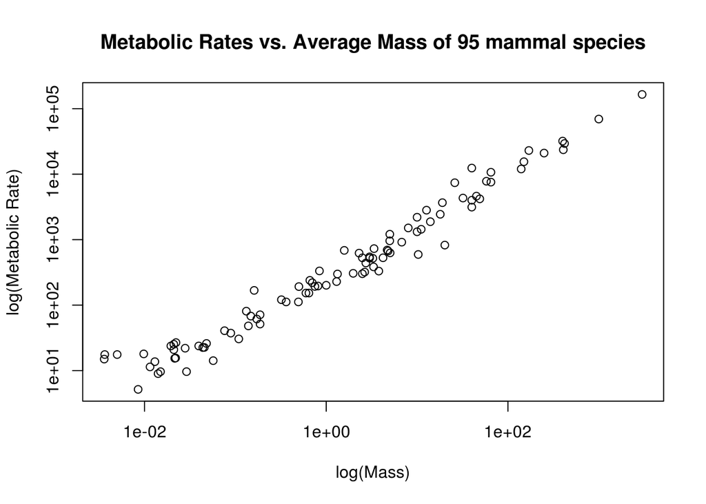

```r
plot(s26$Metab ~ s26$Mass, log = "xy",
     main = "Metabolic Rates vs. Average Mass of 95 mammal species",
     xlab = "log(Mass)",
     ylab = "log(Metabolic Rate)")
```

##### Since the base question is to evaluate if the data set is consistent with Kleiber’s law, an additional transformation is included to raise the Mass to the 3/4 power. This data plot shows similar apparently normal distributions in both x and y axes, and sufficiently linear to proceed with the regression analysis with the data transformed in this manner.

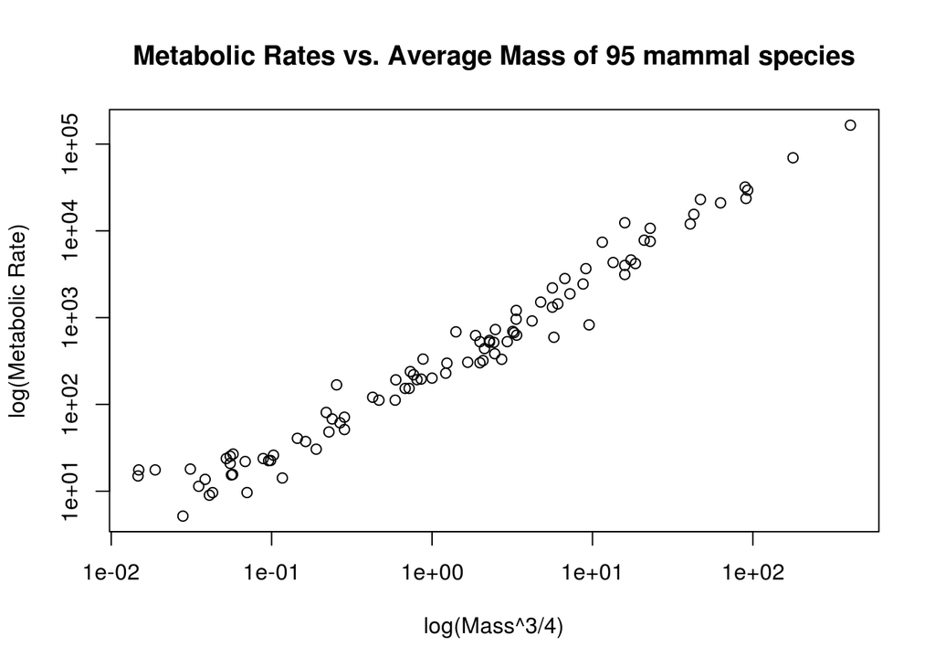

```r
plot(s26$Metab ~ s26$m34, log = "xy",
     main = "Metabolic Rates vs. Average Mass of 95 mammal species",
     xlab = "log(Mass^3/4)",
     ylab = "log(Metabolic Rate)")
```

```r
# ... define data set to analyze

df_xy <- data.frame(s26$log_mass_75, s26$log_metab)

names(df_xy) <- c("log_mass_75", "log_metab")

str(df_xy)
```

```
## 'data.frame':    95 obs. of  2 variables:
##  $ log_mass_75: num  0.687 1.749 0.197 -0.156 0.214 ...
##  $ log_metab  : num  5.71 6.39 5.43 5.28 5.7 ...
```

### Homework 11 - Problem Set 1 - Metabolism

#### b. Analyze the data providing at least the following:

=-=-=-=-=-=-=-=-=-=-=-=-=-=-=-=-=-=-=-=-=-=-=-=-=-=-=-=-=-=-=-=-=-=-=-=–=-=-=-  
**i. A Scatterplot with confidence intervals of the regression line and prediction intervals of the regression line. Please do in SAS and R!**

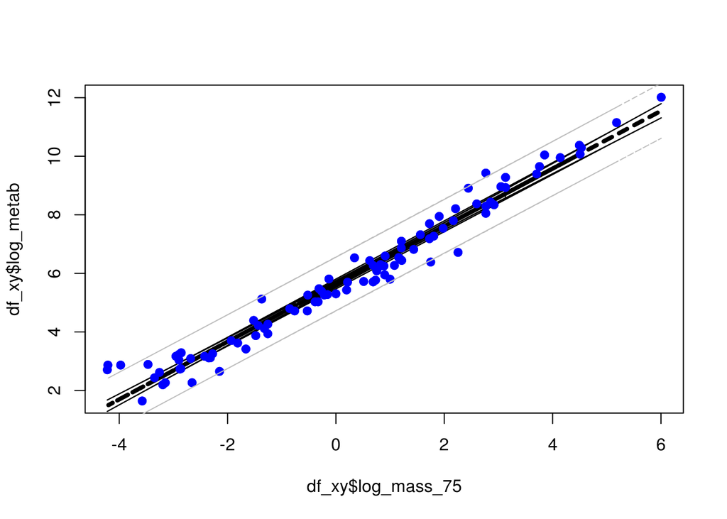

And the SAS plot …

[figure not shown]

SAS Regression Plot

=-=-=-=-=-=-=-=-=-=-=-=-=-=-=-=-=-=-=-=-=-=-=-=-=-=-=-=-=-=-=-=-=-=-=-=–=-=-=-  
**ii. A table showing the t-statistics and pvalues for the significance of the regression parameters: . Please do in SAS and R!**

```
##
## Call:
## lm(formula = log_metab ~ log_mass_75, data = df_xy)
##
## Residuals:
##      Min       1Q   Median       3Q      Max
## -1.14216 -0.26466 -0.04889  0.25308  1.37616
##
## Coefficients:
##             Estimate Std. Error t value Pr(>|t|)
## (Intercept)  5.63833    0.04709  119.73   <2e-16 ***
## log_mass_75  0.98499    0.01949   50.53   <2e-16 ***
## ---
## Signif. codes:  0 '***' 0.001 '**' 0.01 '*' 0.05 '.' 0.1 ' ' 1
##
## Residual standard error: 0.4572 on 93 degrees of freedom
## Multiple R-squared:  0.9649, Adjusted R-squared:  0.9645
## F-statistic:  2553 on 1 and 93 DF,  p-value: < 2.2e-16
```

And the SAS table …

[figure not shown]

SAS Tabular Results of Regression Analysis

=-=-=-=-=-=-=-=-=-=-=-=-=-=-=-=-=-=-=-=-=-=-=-=-=-=-=-=-=-=-=-=-=-=-=-=–=-=-=-  
**iii. Using the data in ii show all 6 steps of each hypothesis test.**  
=-=-=-=-=-=-=-=-=-=-=-=-=-=-=-=-=-=-=-=-=-=-=-=-=-=-=-=-=-=-=-=-=-=-=-=–=-=-=-

##### **Six-Step Hypothesis Test - Slope**

1: Ho : b1 = 0; Ha ; b1 != 0  
2 : Critical Value : t(0.975, df = **93**) = +/- **1.9858018**  
3 : t = 50.5311629  
4 : p_value = 2.018933610^{-69} < 0.05 ?  
5: Reject Ho  
6 : There is sufficient evidence to suggest at the alpha = 0.05 level of significance (p-value = 2.018933610^{-69}) that the slope of the regression line that estimates the Metabolic Rate based on the log(Mass^3/4) of the mammals is not equal to zero. A 95% confidence interval for the slope is ( 0.946, 1.024), which is an interval that does not contain the value zero

=-=-=-=-=-=-=-=-=-=-=-=-=-=-=-=-=-=-=-=-=-=-=-=-=-=-=-=-=-=-=-=-=-=-=-=–=-=-=-  
**iv. The regression equation.**

The Regression equation : * log_metab = 0.9849915 * log_mass_75 + 5.6383307

=-=-=-=-=-=-=-=-=-=-=-=-=-=-=-=-=-=-=-=-=-=-=-=-=-=-=-=-=-=-=-=-=-=-=-=–=-=-=-  
**v. Interpretation of the slope and intercept in the model (regression equation.)**

log - log transformation

y’ = ln y  
x’ = ln x^z, z = 3/4

In this case :  
b0 = 5.6383307  
b1 = 0.9849915  
Therefore, the relationship can be expressed as :  
Metabolic Rate = 280.9932546 * x ^ (0.7387436)

To interpret the meaning of the slope in different terms, for every doubling of the mass of the mammal species, the associated increase in metabolic rate = 2 ^ 0.7387436, or in other words, 1.668722

To interpret the meaning of the intercept in different terms, at the base level for a small species, e.g., mass = 1, the base metabolic rate for all species is expected at a level of 280.9932546

=-=-=-=-=-=-=-=-=-=-=-=-=-=-=-=-=-=-=-=-=-=-=-=-=-=-=-=-=-=-=-=-=-=-=-=–=-=-=-  
**x. A scatterplot of residuals. Please do in SAS and R!**

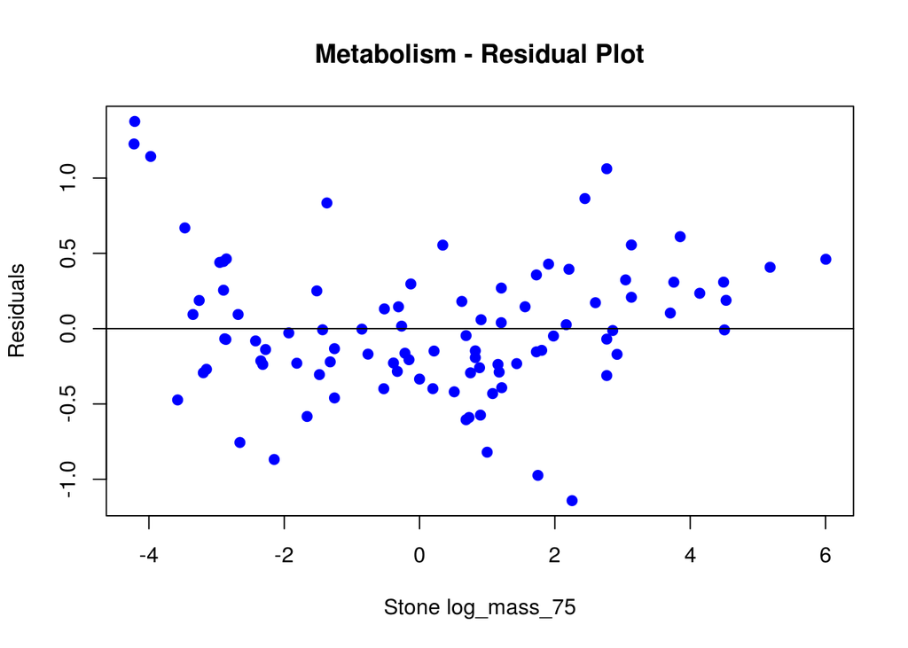

=-=-=-=-=-=-=-=-=-=-=-=-=-=-=-=-=-=-=-=-=-=-=-=-=-=-=-=-=-=-=-=-=-=-=-=–=-=-=-  
**xi. A histogram of residuals with normal distribution superimposed**  
=-=-=-=-=-=-=-=-=-=-=-=-=-=-=-=-=-=-=-=-=-=-=-=-=-=-=-=-=-=-=-=-=-=-=-=–=-=-=-

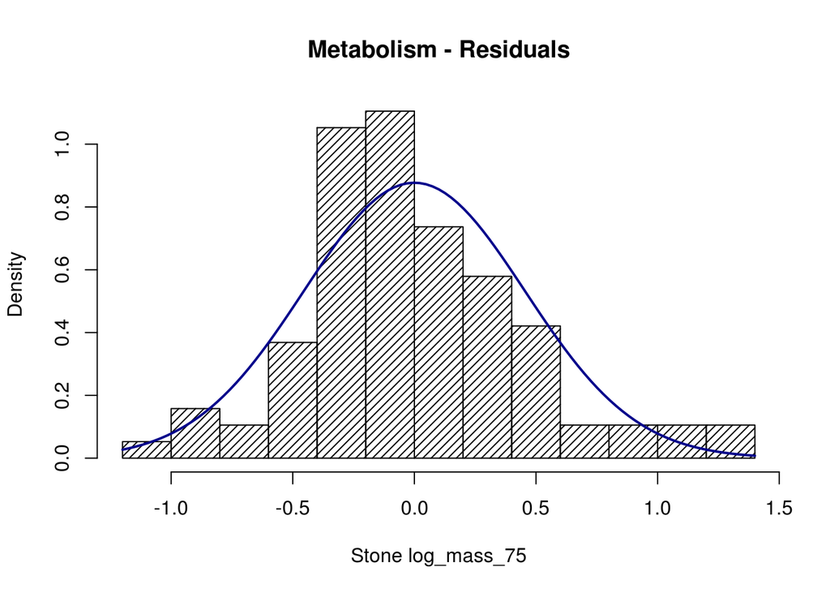

And the SAS plots …

[figure not shown]

SAS - Residuals vs. Predicted Values

[figure not shown]

SAS - Distribution of Residuals

=-=-=-=-=-=-=-=-=-=-=-=-=-=-=-=-=-=-=-=-=-=-=-=-=-=-=-=-=-=-=-=-=-=-=-=–=-=-=-

### **xii. Provide a measure of the amount of variation in the response that is accounted for by the explanatory variable. Interpret this measure clearly indicating the units of the response and the explanatory variables.**

=-=-=-=-=-=-=-=-=-=-=-=-=-=-=-=-=-=-=-=-=-=-=-=-=-=-=-=-=-=-=-=-=-=-=-=–=-=-=-

```r
r2 <- summary.lm(fit_all, r.squared=TRUE)$r.squared
r2_format <- sprintf("%8.2f %%", r2*100)
non_r2_format <- sprintf("%8.2f %%", (1.0 - r2)*100)
```

#### R-squared value for model = 0.9648579

#### Therefore, 96.49 % of the variation observed in the dependent variable (log(Metabolism) is explained by the log(mass^3/4) independent variable, leaving only 3.51 % variation that is available to be explained by any remaining contributory factors.